# Writing an R Package Basics (and why I think you should)

Daniel Anderson

2018-04-24

On April 10, 2018, I gave a talk entitled [Developing your first R package: A case study with *esvis*](http://www.dandersondata.com/talks/eugene_rug/) for the [Eugene R Users Group](https://www.meetup.com/meetup-group-cwPiAlnB/). Although I discussed my esvis package, the focus of the talk was really on tools and tips for developing R pacakges. In this post, I’ll go over some of the content in that talk, and discuss *why* I think you should develop an R package.

## Writing functions is the hard part

The first point I want to make is that compiling functions into a package is not overly difficult, particularly given all the tools that are now available to help make the process as pain-free as possible (e.g., [{usethis}](https://www.tidyverse.org/articles/2017/11/usethis-1.0.0/), [{devtools}](https://github.com/r-lib/devtools/tree/master/R), [{roxygen2}](https://github.com/klutometis/roxygen)). Writing functions is the hard part, but you can do that too.

Let’s say you have some code that looks like this

```r
library(tidyverse)
mtcars %>%
  summarize(n_obs = n(),
            mean  = mean(mpg),
            sd    = sd(mpg))
```

```
##   n_obs     mean       sd
## 1    32 20.09062 6.026948
```

and we want to extend this code so we can calculate these same descriptives for any numeric column in any data frame. How? We write a function!

To replicate the code above exactly as a function, we’d have to use [tidyeval](https://dplyr.tidyverse.org/articles/programming.html) (see my [use case here](http://www.dandersondata.com/post/a-tidyeval-use-case/)). Instead, I’ll just move to some base functions to make it a little easier. I also regularly have to worry about missing data, so I’ll extend it a bit to give us some information about the amount of missingness.

```r
describe <- function(var) {
  miss  <- sum(is.na(var))

  var     <- na.omit(var)
  valid   <- length(var)
  mn      <- mean(var)
  stdev   <- sd(var)

  data.frame(n_miss  = miss,
             n_valid = valid,
             mean    = mn,
             sd      = stdev)
}
```

The above creates a new function, called `describe`, which sums the number of missing cases (this works because logicals are implicitly coerced to numeric, where `TRUE == 1` and `FALSE == 0`), removes all missing data, calculates the length of the variable (vector) with missing data removed, calculates the mean, calculates the standard deviation, and then compiles it all into a data frame. Let’s test it out

```r
describe(mtcars$mpg)
```

```
##   n_miss n_valid     mean       sd
## 1      0      32 20.09062 6.026948
```

```r
describe(iris$Sepal.Width)
```

```
##   n_miss n_valid     mean        sd
## 1      0     150 3.057333 0.4358663
```

```r
set.seed(04242018)
describe(c(rnorm(1e5, 100, 3), rep(NA, 500)))
```

```
##   n_miss n_valid     mean       sd
## 1    500  100000 99.98689 3.007097
```

So all appears well.

In my talk, I recommended taking the following steps

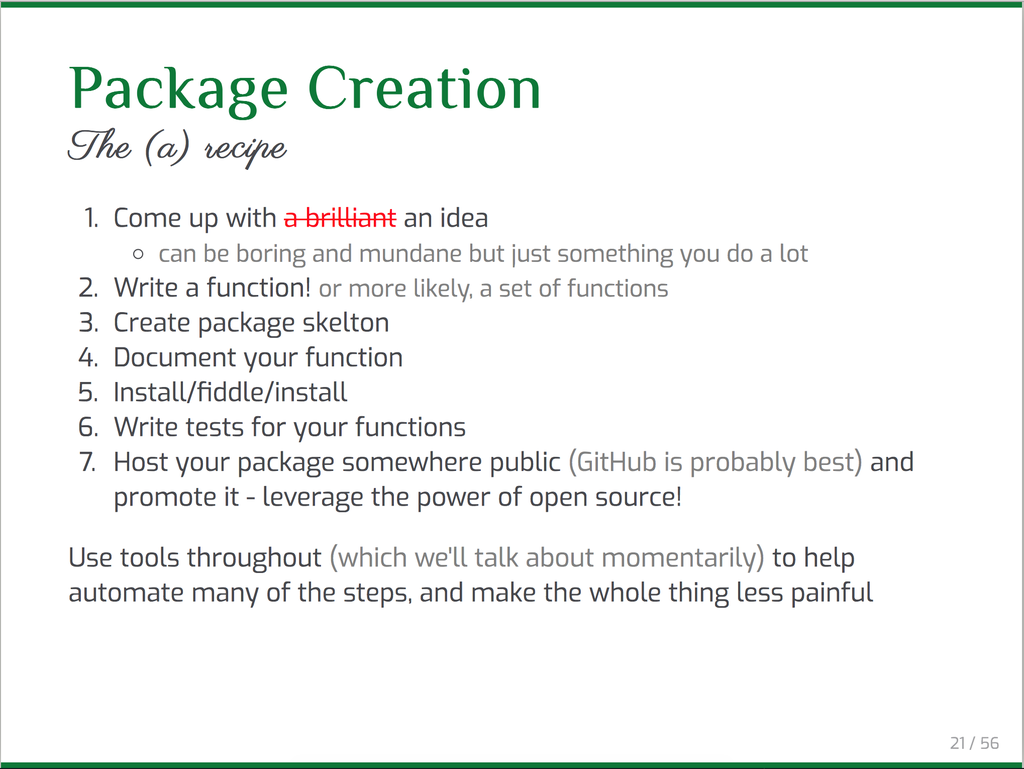

There was some initial confusion on the twitterverse about what I meant by Step 3. To be clear, I am 100% recommending you use `usethis::create_package`, which I would consider a package skeleton, but that should **not** be confused with `utils::package.skeleton`, which I would argue is much less friendly to the developer.

So, following the above, we have an idea (basic descriptive stats), we have a function, so now we need to create the package skeleton.

#### Create a package skeleton with `usethis`

The way I would recommend doing this, so you don’t have to worry about paths at all is:

1. Create a new R Project in a new directory

[figure not shown]

- Select new project (not R Package)

[figure not shown]

- Give your project whatever name you want your package to have

[figure not shown]

2. Run `usethis::create_package(".")`, which says “Create a package here”. It will then prompt you to make sure you want to overwrite the existing project you just created. Just say yes, and it will launch a new project (you can close the old one).

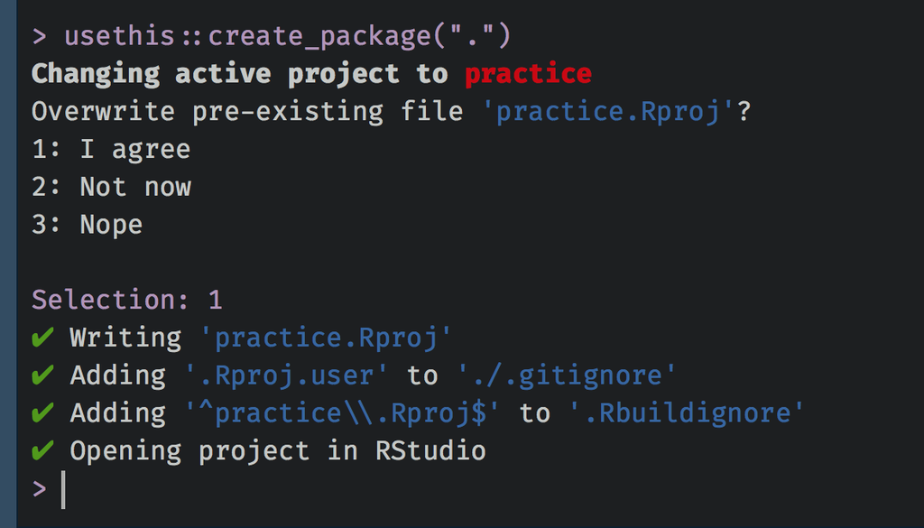

If all has gone well, you should see a new batch of files and folders in the directory.

[figure not shown]

Notice that one of these folders is called “R”. This is where all your functions go. Save them in a `.R` script, and we’ll move on to Step 4: Document your function.

#### Document your function

Function in R packages generally include documentation. For example if you run `?lm` you will get the documentation for the `lm` function for linear modeling, which looks like this:

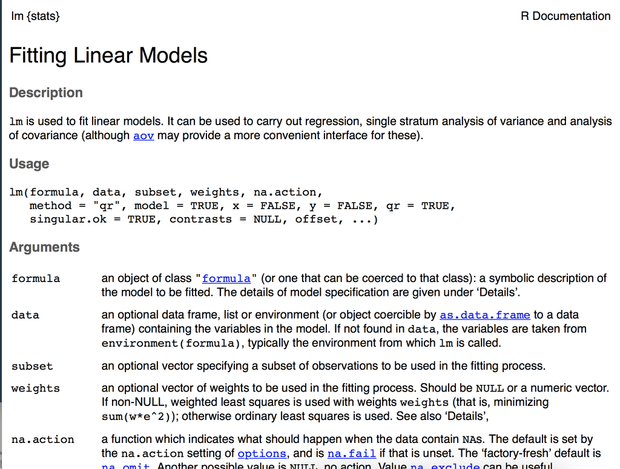

We’re going to annotate our R script for our function using specialized comments. Those comments will then be automatically rendered into the documentation pages, like the one shown above, by the [{roxygen2}](https://github.com/klutometis/roxygen) package. The comments are `#'`, rather than just pound signs, and then you’ll describe specific parts of the function using parameters like `@param`, `@return`, `@export`, and `@examples`. These four, specifically, are probably the most common, and most important. `@param` describes the arguments, `@return` describes what the function will return, `@export` makes the function available upon loading the pacakge (rather than an internal function), and `@examples` provides example usage of the function. Below is an example of how I’ve documented our function written earlier.

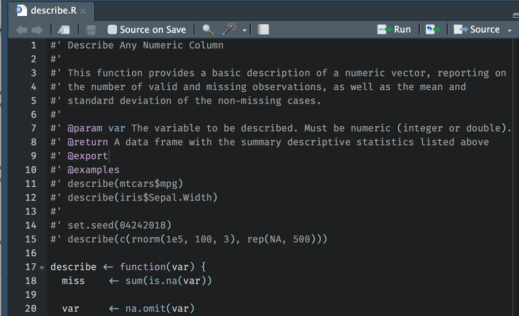

If you look in the `\man` folder there is currently nothing there. However, after writing the documentation, we can run `devtools::document()` and it will render the specialized comments into the documentation we need (i.e., there will be documents in the `\man` folder corresponding to the documentation for our function).

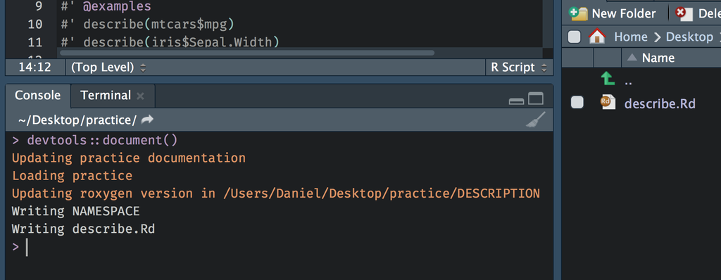

#### Install/fiddle/install

At this point, we’re almost ready to go. If you click on the “Build” tab you will see a “Install and Restart” option.

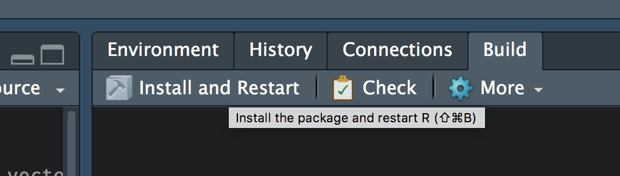

Just clicking this button will install the package on your computer, and restart your local R session. You can now run `?describe` and you’ll see the documentation for your function (see below). You can also play around with the function, run tests, etc.

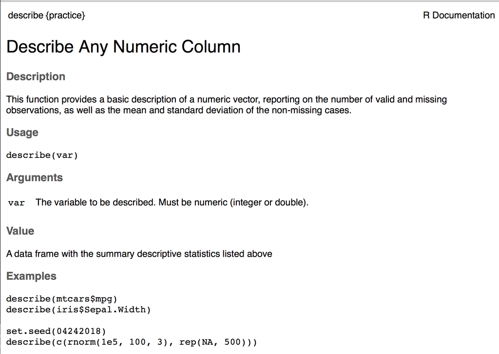

## What’s the benefit?

The above basically helps get you started with writing R packages, but it’s obviously not everything you need to know. But what’s the benefit of all this? I would argue a few things. First, if you’re writing functions and using them more than once, it’s a great way to stay organized and make your functions more accessible. Part of what is so cool about the above, is that now, in any R session, regardless of our working directory or anything else, we should be able to call `library(practice)` and the `describe` function will be available to us.

Second, as you start to write packages, you will naturally run across stumbling blocks. Although these can be frustrating at times, they will actually help push your knowledge and make you a a better programmer.

Third, and finally, particularly if you house your package on [GitHub](https://github.com), sharing the functionality of your package with others will be easier (which may help people become more interested in R and the work you’re doing). Further, if you house your code on GitHub, you’ll be open and transparent (which sometimes can be a little scary, but the R community is incredibly welcoming), and others may help you make your code better! Leverage the power of open source!

## It doesn’t have to be a package for release

When I first announced I was giving this talk on twitter, [Alison Hill](https://alison.rbind.io) [helped promote it](https://twitter.com/apreshill/status/983554271827259397) by taking a screen capture of my recipe slide, above. This prompted the following comment by [Maëlle Salmon](http://www.masalmon.eu)

> 1a) check that no one had the same idea 😇

> — Maëlle Salmon 🐟 (@ma_salmon) [April 10, 2018](https://twitter.com/ma_salmon/status/983572108474241025?ref_src=twsrc%5Etfw)

I think this is an excellent point, and Maëlle even has a [blog post](http://www.masalmon.eu/2017/12/11/goodrpackages/) about this topic. In that post she states

> I won’t speak about the [benefits of building an R package for yourself](http://r-pkgs.had.co.nz/intro.html), or a [research compendium](https://github.com/ropensci/unconf17/issues/5) to make your work reproducible.